# R Notebook

```r
library(readr)
ArrestIncidents <- read_csv("ArrestIncidents.csv")
head(ArrestIncidents)
```

| DATE | TEAM | NAME | POSITION | CASE | CATEGORY | DESCRIPTION | OUTCOME | VIOLENT |
| --- | --- | --- | --- | --- | --- | --- | --- | --- |
| 3/27/2017 | SEA | Trevone Boykin | Quarterback | Arrested | Drugs | Accused of marijuana possession, public intoxication. He was a passenger in a car involved in accident in Dallas. | Resolution undetermined. | 0 |
| 3/26/2017 | CHI | Deiondre Hall | Cornerback | Arrested | Disorderly conduct | Accused of disorderly conduct, public intoxication and interference outside bar in Cedar Falls, Iowa. | Resolution undetermined. | 0 |
| 3/26/2017 | GB | Makinton Dorleant | Cornerback | Arrested | Police interference | Accused of interfence after scuffle outside of bar in Cedar Falls, Iowa. | Resolution undetermined. | 0 |
| 3/7/2017 | KC | Demetrius Harris | Tight End | Arrested | Drugs | Suspected of felony marijuana possession as passenger in car pulled over in Missouri. | Resolution undetermined. | 0 |
| 3/5/2017 | LAR | Ethan Westbrooks | Defensive Tackle | Arrested | Domestic violence | Suspected of domestic violence in Sacramento after police observed injuries to mother of his child. | Resolution undetermined. | 1 |
| 2/25/2017 | IND | David Parry | Defensive Tackle | Arrested | DUI, resisting arrest | Suspected of stealing golf cart, driving drunk, resisting arrest in Scottsdale, Ariz. | Resolution undetermined. | 0 |

```r
ViolentArrests <-ArrestIncidents[(ArrestIncidents$VIOLENT == 1 & ArrestIncidents$CASE == 'Arrested'),]
head(ViolentArrests)
```

| DATE | TEAM | NAME | POSITION | CASE | CATEGORY | DESCRIPTION | OUTCOME | VIOLENT |
| --- | --- | --- | --- | --- | --- | --- | --- | --- |
| 3/5/2017 | LAR | Ethan Westbrooks | Defensive Tackle | Arrested | Domestic violence | Suspected of domestic violence in Sacramento after police observed injuries to mother of his child. | Resolution undetermined. | 1 |
| 1/2/2017 | CIN | Adam Jones | Cornerback | Arrested | Assault | Accused of poking hotel security employee in the eye in Cincinnati, obstructing police. | Resolution undetermined. | 1 |
| 9/5/2016 | SF | Bruce Miller | Tight End | Arrested | Assault | Accused of assaulting a man and his 70-year-old father at hotel in San Francisco. | Resolution undetermined. Team released him same day. | 1 |
| 7/25/2016 | PHI | Nigel Bradham | Linebacker | Arrested | Assault | Suspected of punching somebody in the nose at a Miami Beach hotel after verbal altercation. | Resolution undetermined. | 1 |
| 6/19/2016 | JAC | Dan Skuta | Linebacker | Arrested | Battery | Accused of pushing a woman's face with an open hand after she refused to give him her phone number in Orlando. | Dropped by prosecutors. | 1 |
| 1/23/2016 | NE | J.J. Worton | Wide Receiver | Arrested | Assault | Accused of assault and battery after fight at a bar in Foxboro, Mass. | Pleaded guilty to misdemeanors. | 1 |

#Head Injuries & Arrests

```r
library(readr)
Head_Injured_Players <- read_csv("Head Injured Players.csv")
head(Head_Injured_Players)
```

| Player | 2012/2013 - Number of Injuries | 2012/2013 - Games Missed | 2013/2014 - Number of Injuries | 2013/2014 - Games Missed | 2014/2015 - Number of Injuries | 2014/2015 - Games Missed | Total Number of Injuries (2012-2014) | Total Games Missed (2012-2014) | Age first concussion (2012-2014) | Team(s) during concussion incidents 2012-2014 | Roles during injuries | Current Age (approx.) | Date of Birth | Biography | Wikipedia Url | Image |
| --- | --- | --- | --- | --- | --- | --- | --- | --- | --- | --- | --- | --- | --- | --- | --- | --- |
| DeAndre Hopkins | NA | NA | 1 | 0 | NA | NA | 1 | 0 | 21.26 | Houston Texans | Wide Receiver | 22 | 6/6/1992 | DeAndre Rashaun Hopkins (born June 6, 1992), also known as " Nuk ," is an American football wide receiver for the Houston Texans of the National Football League (NFL). He played college football for C… | http://en.wikipedia.org/wiki/DeAndre_Hopkins | //upload.wikimedia.org/wikipedia/commons/6/60/DeAndre_Hopkins.JPG |
| Le'Veon Bell | NA | NA | 1 | 0 | NA | NA | 1 | 0 | 21.78 | Pittsburgh Steelers | Running Back | 23 | 18/02/1992 | Le'Veon Bell (pronounced LAY-vee-on; born February 18, 1992) is an American football running back for the Pittsburgh Steelers of the National Football League (NFL). He played college football for Mich… | http://en.wikipedia.org/wiki/Le'Veon_Bell | //upload.wikimedia.org/wikipedia/commons/b/b7/LeVeon_Bell_26_practing_2013.jpg |
| Tony Jefferson | NA | NA | NA | NA | 1 | 0 | 1 | 0 | 22.75 | Arizona Cardinals | Safety | 23 | 27/01/1992 | Tony Jefferson (born January 27, 1992) is an American football safety who currently plays for the Arizona Cardinals of the National Football League. Jefferson was a 2010 Freshman All-American by Colle… | http://en.wikipedia.org/wiki/Tony_Jefferson | http://a.espncdn.com/combiner/i?img=/i/headshots/nfl/players/full/16195.png |
| James Wright | NA | NA | NA | NA | 1 | 0 | 1 | 0 | 22.68 | Cincinnati Bengals | Wide Receiver | 23 | 31/12/1991 | James Earl Wright (born December 31, 1991) is an American football wide receiver for the Cincinnati Bengals of the National Football League. He played college football at LSU. | http://en.wikipedia.org/wiki/James_Wright_(wide_receiver) | http://a.espncdn.com/combiner/i?img=/i/headshots/nfl/players/full/16922.png |
| Joseph Randle | NA | NA | NA | NA | 1 | 0 | 1 | 0 | 22.71 | Dallas Cowboys | Running Back | 23 | 29/12/1991 | Joseph Randle (born December 29, 1991) is an American football running back for the Dallas Cowboys in the National Football League. He played college football for the Oklahoma State Cowboys. In the 20… | http://en.wikipedia.org/wiki/Joseph_Randle | http://a.espncdn.com/combiner/i?img=/i/headshots/nfl/players/full/16013.png |
| Corey Brown | NA | NA | NA | NA | 1 | 3 | 1 | 3 | 22.84 | Carolina Panthers | Wide Receiver | 23 | 16/12/1991 | Corey Phillip "Philly" Brown (born December 16, 1991) is an American football wide receiver and return specialist for the Carolina Panthers of the National Football League (NFL). He played college foo… | http://en.wikipedia.org/wiki/Philly_Brown | http://a.espncdn.com/combiner/i?img=/i/headshots/nfl/players/full/17399.png |

```r
Head_Injured_Players$`Roles during injuries` <- as.factor(Head_Injured_Players$`Roles during injuries`)
attributes(Head_Injured_Players$`Roles during injuries`)
```

```
$levels
 [1] "Center"           "Cornerback"       "Defensive End"    "Defensive Tackle" "Full Back"        "Guard"            "Linebacker"       "Long Snapper"     "Offensive Tackle" "Quarterback"
[11] "Running Back"     "Safety"           "Tight End"        "Wide Receiver"

$class
[1] "factor"
```

```r
injuries.positions <- aggregate(Head_Injured_Players$`Total Number of Injuries (2012-2014)`, by=list(Role = Head_Injured_Players$`Roles during injuries`), FUN = sum)
head(injuries.positions)
```

|  | Role | x |
| --- | --- | --- |
| 1 | Center | 7 |
| 2 | Cornerback | 62 |
| 3 | Defensive End | 19 |
| 4 | Defensive Tackle | 13 |
| 5 | Full Back | 3 |
| 6 | Guard | 26 |

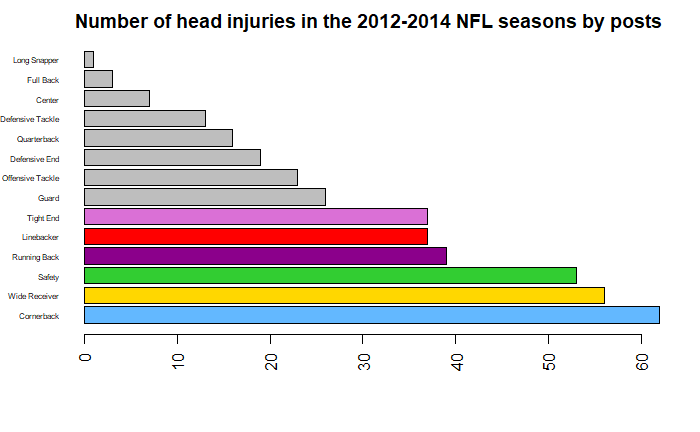

```r
injuries.positions <- injuries.positions[order(injuries.positions[,2],decreasing=TRUE),]

colnames(injuries.positions) <- c("Position", "Number of injuries")
par(las=2)
barplot(injuries.positions$`Number of injuries`,
        names = injuries.positions$Position,
        col = ifelse(injuries.positions$Position == 'Linebacker' ,'red', ifelse(injuries.positions$Position == 'Cornerback' ,'steelblue1', ifelse(injuries.positions$Position == 'Wide Receiver' ,'gold', ifelse(injuries.positions$Position == 'Safety' ,'limegreen', ifelse(injuries.positions$Position == 'Running Back' ,'darkmagenta', ifelse(injuries.positions$Position == 'Tight End' ,'orchid', 'grey')))))),
        horiz = TRUE,
        cex.names = .5,
        main="Number of head injuries in the 2012-2014 NFL seasons by posts")
```

A továbbiakban leginkább a 6 más színnel jelölt poszton lesz a hangsúly, mivel ők a legérdekesebbek a szempontunkból. Mint látható a legtöbb fejsérülést az olyan poszton játszók szenvedték el, akik nagy sebességgel ütköznek (Safety, Wide Receiver, Cornerback).

```r
ViolentArrests$POSITION <- as.factor(ViolentArrests$POSITION)
attributes(ViolentArrests$POSITION)
```

```
$levels
 [1] "Center"           "Cornerback"       "Defensive End"    "Defensive Tackle" "Full Back"        "Guard"            "Kicker"           "Linebacker"       "Offensive Tackle" "Running Back"
[11] "Safety"           "Tight End"        "Wide Receiver"

$class
[1] "factor"
```

```r
arrests.position <- aggregate(ViolentArrests$VIOLENT, by=list(Role = ViolentArrests$POSITION), FUN = sum)
head(arrests.position)
```

|  | Role | x |
| --- | --- | --- |
| 1 | Center | 1 |
| 2 | Cornerback | 21 |
| 3 | Defensive End | 13 |
| 4 | Defensive Tackle | 15 |
| 5 | Full Back | 1 |
| 6 | Guard | 5 |

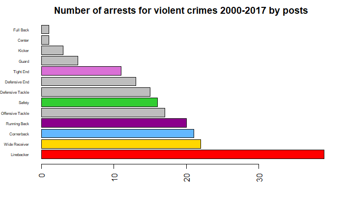

```r
arrests.position <- arrests.position[order(arrests.position[,2],decreasing=TRUE),]


colnames(arrests.position) <- c("Position", "Number of arrests")
par(las=2)
barplot(arrests.position$`Number of arrests`,
        names = arrests.position$Position,
        col = ifelse(arrests.position$Position == 'Linebacker' ,'red', ifelse(arrests.position$Position == 'Cornerback' ,'steelblue1', ifelse(arrests.position$Position == 'Wide Receiver' ,'gold', ifelse(arrests.position$Position == 'Safety' ,'limegreen', ifelse(arrests.position$Position == 'Running Back' ,'darkmagenta', ifelse(arrests.position$Position == 'Tight End' ,'orchid', 'grey')))))),
        horiz = TRUE,
        cex.names = .5,
        main="Number of arrests for violent crimes 2000-2017 by posts")
```

Viszont mint ahogy itt láthatjuk, annak ellenére, hogy az adott intervallumban a Linebackerek csak az ötödik legtöbb fejsérülést szenvedték az adott időintervallum alatt, mégis magasan ők követik el a legtöbb erőszakos bűncselekményt.

```r
ArrestsAndInjuries <- merge(arrests.position, injuries.positions,  by = 'Position')
head(ArrestsAndInjuries)
```

|  | Position | Number of arrests | Number of injuries |
| --- | --- | --- | --- |
| 1 | Center | 1 | 7 |
| 2 | Cornerback | 21 | 62 |
| 3 | Defensive End | 13 | 19 |
| 4 | Defensive Tackle | 15 | 13 |
| 5 | Full Back | 1 | 3 |
| 6 | Guard | 5 | 26 |

```r
inj.without.linebackers <- ArrestsAndInjuries[(ArrestsAndInjuries$Position != 'Linebacker'),]
head(inj.without.linebackers)
```

|  | Position | Number of arrests | Number of injuries |
| --- | --- | --- | --- |
| 1 | Center | 1 | 7 |
| 2 | Cornerback | 21 | 62 |
| 3 | Defensive End | 13 | 19 |
| 4 | Defensive Tackle | 15 | 13 |
| 5 | Full Back | 1 | 3 |
| 6 | Guard | 5 | 26 |

```r
plot(ArrestsAndInjuries$`Number of injuries`, ArrestsAndInjuries$`Number of arrests`, type = "n")
text(ArrestsAndInjuries$`Number of injuries`, ArrestsAndInjuries$`Number of arrests`, labels = ArrestsAndInjuries$Position, cex=0.7,col = ifelse(ArrestsAndInjuries$Position == 'Linebacker' ,'red', ifelse(ArrestsAndInjuries$Position == 'Cornerback' ,'steelblue1', ifelse(ArrestsAndInjuries$Position == 'Wide Receiver' ,'gold', ifelse(ArrestsAndInjuries$Position == 'Safety' ,'limegreen', ifelse(ArrestsAndInjuries$Position == 'Running Back' ,'darkmagenta', ifelse(ArrestsAndInjuries$Position == 'Tight End' ,'orchid', 'black')))))),)
```

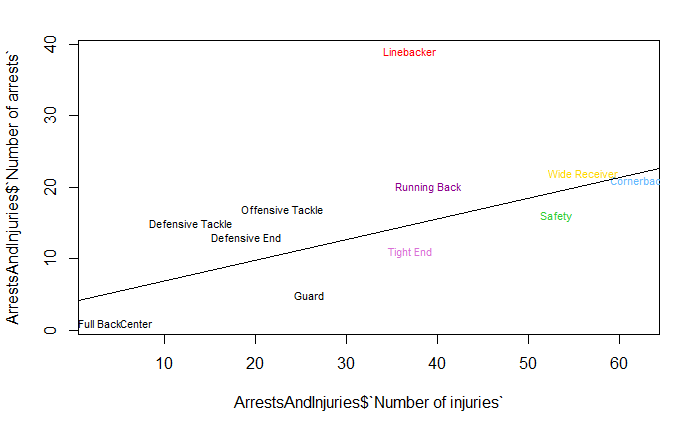

```r
abline(lm(inj.without.linebackers$`Number of arrests`~ inj.without.linebackers$`Number of injuries` ))
```

Ez látszódik ezen az ábrán is. Az egyenes a linebackerek nélküli átlagot mutatja, mint látható a poszt jóval felette helyezkedik el.

#Concussion & arrests

```r
library(readr)
Concussion_Injuries_2012_2014 <- read_csv("Concussion Injuries 2012-2014.csv")
```

```r
Concussion_Injuries_2012_2014$Position <- as.factor(Concussion_Injuries_2012_2014$Position)
attributes(Concussion_Injuries_2012_2014$Position)
```

```
$levels
 [1] "Center"           "Cornerback"       "Defensive End"    "Defensive Tackle" "Full Back"        "Guard"            "Linebacker"       "Long Snapper"     "Offensive Tackle" "Quarterback"
[11] "Running Back"     "Safety"           "Tight End"        "Wide Receiver"

$class
[1] "factor"
```

```r
conc.positions <- aggregate(Concussion_Injuries_2012_2014$ID, by=list(Role = Concussion_Injuries_2012_2014$Position), FUN = length)
head(conc.positions)
```

|  | Role | x |
| --- | --- | --- |
| 1 | Center | 7 |
| 2 | Cornerback | 64 |
| 3 | Defensive End | 20 |
| 4 | Defensive Tackle | 13 |
| 5 | Full Back | 3 |
| 6 | Guard | 26 |

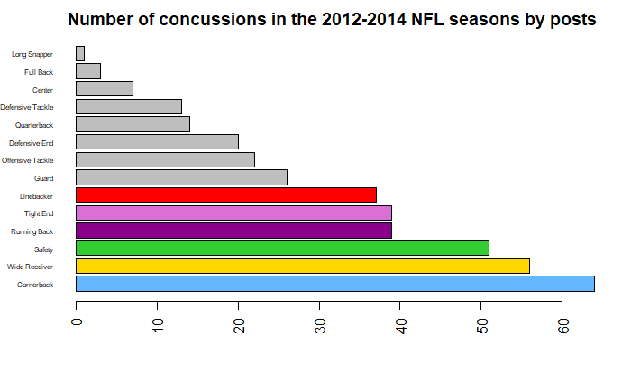

```r
conc.positions <- conc.positions[order(conc.positions[,2],decreasing=TRUE),]

colnames(conc.positions) <- c("Position", "Number of injuries")
par(las=2)
barplot(conc.positions$`Number of injuries`,
        names = conc.positions$Position,
        col = ifelse(conc.positions$Position == 'Linebacker' ,'red', ifelse(conc.positions$Position == 'Cornerback' ,'steelblue1', ifelse(conc.positions$Position == 'Wide Receiver' ,'gold', ifelse(conc.positions$Position == 'Safety' ,'limegreen', ifelse(conc.positions$Position == 'Running Back' ,'darkmagenta', ifelse(conc.positions$Position == 'Tight End' ,'orchid', 'grey')))))),
        horiz = TRUE,
        cex.names = .5,
        main="Number of concussions in the 2012-2014 NFL seasons by posts")
```

Ezért megnéztem, hogy a kizárólag agyrázkódások terén hogyan mutatnak a posztok, de a Linebackerek itt méghátrébb sorolódtak.

```r
ArrestsAndConcussions <- merge(arrests.position, conc.positions,  by = 'Position')
head(ArrestsAndConcussions)
```

|  | Position | Number of arrests | Number of injuries |
| --- | --- | --- | --- |
| 1 | Center | 1 | 7 |
| 2 | Cornerback | 21 | 64 |
| 3 | Defensive End | 13 | 20 |
| 4 | Defensive Tackle | 15 | 13 |
| 5 | Full Back | 1 | 3 |
| 6 | Guard | 5 | 26 |

```r
conc.without.linebackers <- ArrestsAndConcussions[(ArrestsAndConcussions$Position != 'Linebacker'),]
head(conc.without.linebackers)
```

|  | Position | Number of arrests | Number of injuries |
| --- | --- | --- | --- |
| 1 | Center | 1 | 7 |
| 2 | Cornerback | 21 | 64 |
| 3 | Defensive End | 13 | 20 |
| 4 | Defensive Tackle | 15 | 13 |
| 5 | Full Back | 1 | 3 |
| 6 | Guard | 5 | 26 |

```r
plot(ArrestsAndConcussions$`Number of injuries`, ArrestsAndConcussions$`Number of arrests`,  type = "n")
text(ArrestsAndConcussions$`Number of injuries`, ArrestsAndConcussions$`Number of arrests`, labels = ArrestsAndConcussions$Position, cex=0.7, col = ifelse(ArrestsAndConcussions$Position == 'Linebacker' ,'red', ifelse(ArrestsAndConcussions$Position == 'Cornerback' ,'steelblue1', ifelse(ArrestsAndConcussions$Position == 'Wide Receiver' ,'gold', ifelse(ArrestsAndConcussions$Position == 'Safety' ,'limegreen', ifelse(ArrestsAndConcussions$Position == 'Running Back' ,'darkmagenta', ifelse(ArrestsAndConcussions$Position == 'Tight End' ,'orchid', 'black')))))))
```

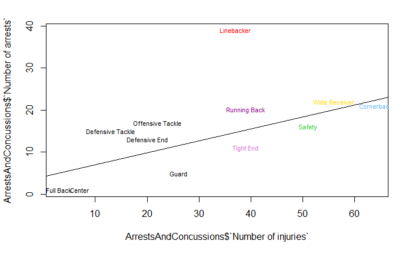

```r
abline(lm(conc.without.linebackers$`Number of arrests`~ conc.without.linebackers$`Number of injuries` ))
```

Egyértelműen nem segített a helyzeten, még mindig kiugró értéket mutat.

#All Arrests

```r
Arrests <-ArrestIncidents[(ArrestIncidents$CASE == 'Arrested'),]
head(Arrests)
```

| DATE | TEAM | NAME | POSITION | CASE | CATEGORY | DESCRIPTION | OUTCOME | VIOLENT |
| --- | --- | --- | --- | --- | --- | --- | --- | --- |
| 3/27/2017 | SEA | Trevone Boykin | Quarterback | Arrested | Drugs | Accused of marijuana possession, public intoxication. He was a passenger in a car involved in accident in Dallas. | Resolution undetermined. | 0 |
| 3/26/2017 | CHI | Deiondre Hall | Cornerback | Arrested | Disorderly conduct | Accused of disorderly conduct, public intoxication and interference outside bar in Cedar Falls, Iowa. | Resolution undetermined. | 0 |
| 3/26/2017 | GB | Makinton Dorleant | Cornerback | Arrested | Police interference | Accused of interfence after scuffle outside of bar in Cedar Falls, Iowa. | Resolution undetermined. | 0 |
| 3/7/2017 | KC | Demetrius Harris | Tight End | Arrested | Drugs | Suspected of felony marijuana possession as passenger in car pulled over in Missouri. | Resolution undetermined. | 0 |
| 3/5/2017 | LAR | Ethan Westbrooks | Defensive Tackle | Arrested | Domestic violence | Suspected of domestic violence in Sacramento after police observed injuries to mother of his child. | Resolution undetermined. | 1 |
| 2/25/2017 | IND | David Parry | Defensive Tackle | Arrested | DUI, resisting arrest | Suspected of stealing golf cart, driving drunk, resisting arrest in Scottsdale, Ariz. | Resolution undetermined. | 0 |

```r
Arrests$POSITION <- as.factor(Arrests$POSITION)
attributes(Arrests$POSITION)
```

```
$levels
 [1] "Center"           "Cornerback"       "Defensive End"    "Defensive Tackle" "Full Back"        "Guard"            "Kicker"           "Linebacker"       "Offensive Tackle" "Punter"
[11] "Quarterback"      "Running Back"     "Safety"           "Tight End"        "Wide Receiver"

$class
[1] "factor"
```

```r
allArrests.positions <- aggregate(Arrests$CASE, by=list(Role = Arrests$POSITION), FUN = length)
allArrests.positions <- allArrests.positions[order(allArrests.positions[,2],decreasing=TRUE),]
head(allArrests.positions)
```

|  | Role | x |
| --- | --- | --- |
| 15 | Wide Receiver | 115 |
| 8 | Linebacker | 102 |
| 2 | Cornerback | 95 |
| 12 | Running Back | 75 |
| 4 | Defensive Tackle | 69 |
| 13 | Safety | 66 |

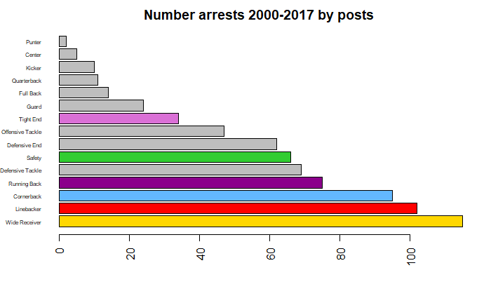

```r
colnames(allArrests.positions) <- c("Position", "Number of arrests")
par(las=2)
barplot(allArrests.positions$`Number of arrests`,
        names = allArrests.positions$Position,
        col = ifelse(allArrests.positions$Position == 'Linebacker' ,'red', ifelse(allArrests.positions$Position == 'Cornerback' ,'steelblue1', ifelse(allArrests.positions$Position == 'Wide Receiver' ,'gold', ifelse(allArrests.positions$Position == 'Safety' ,'limegreen', ifelse(allArrests.positions$Position == 'Running Back' ,'darkmagenta', ifelse(allArrests.positions$Position == 'Tight End' ,'orchid', 'grey')))))),
        horiz = TRUE,
        cex.names = .5,
        main="Number arrests 2000-2017 by posts")
```

Ugyan az agyrázkódások okozta CTE miatt kialakuló erőszakos viselkedést próbáltam vizsgálni, de a linebackerek miatt kíváncsi voltam, hogy vajon az összes bűntény elkövetése tekintetében mit mutatnak ezek a számok. Mint látható itt a linebackerek már a második legtöbb bűntény elkövetésével ‘büszkélkedhetnek’.

```r
AllArrestsAndInjuries <- merge(allArrests.positions, conc.positions,  by = 'Position')
head(AllArrestsAndInjuries)
```

|  | Position | Number of arrests | Number of injuries |
| --- | --- | --- | --- |
| 1 | Center | 5 | 7 |
| 2 | Cornerback | 95 | 64 |
| 3 | Defensive End | 62 | 20 |
| 4 | Defensive Tackle | 69 | 13 |
| 5 | Full Back | 14 | 3 |
| 6 | Guard | 24 | 26 |

```r
plot(AllArrestsAndInjuries$`Number of injuries`, AllArrestsAndInjuries$`Number of arrests`,  type = "n")
text(AllArrestsAndInjuries$`Number of injuries`, AllArrestsAndInjuries$`Number of arrests`, labels = AllArrestsAndInjuries$Position, cex=0.7, col = ifelse(AllArrestsAndInjuries$Position == 'Linebacker' ,'red', ifelse(AllArrestsAndInjuries$Position == 'Cornerback' ,'steelblue1', ifelse(AllArrestsAndInjuries$Position == 'Wide Receiver' ,'gold', ifelse(AllArrestsAndInjuries$Position == 'Safety' ,'limegreen', ifelse(AllArrestsAndInjuries$Position == 'Running Back' ,'darkmagenta', ifelse(AllArrestsAndInjuries$Position == 'Tight End' ,'orchid', 'black')))))))
```

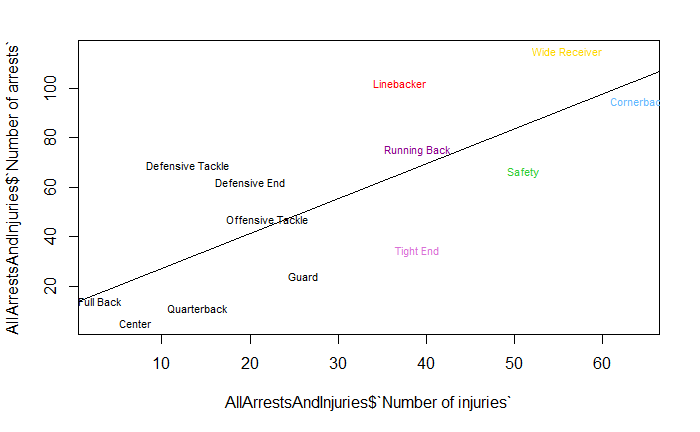

```r
abline(lm(AllArrestsAndInjuries$`Number of arrests`~ AllArrestsAndInjuries$`Number of injuries`))
```

És mint látható, még mindig a várható érték felett helyezkednek el, de már nem akkora a különbség.

#Snaps after injury

```r
snaps.positions <- aggregate(Concussion_Injuries_2012_2014$`Play Time After Injury`, by =list(Role = Concussion_Injuries_2012_2014$Position), FUN=mean, na.rm=TRUE)
snaps.positions
```

| Role | x |
| --- | --- |
| Center | 63.57143 |
| Cornerback | 48.57627 |
| Defensive End | 39.22222 |
| Defensive Tackle | 27.76923 |
| Full Back | 29.00000 |
| Guard | 53.28000 |
| Linebacker | 41.58621 |
| Long Snapper | 12.00000 |
| Offensive Tackle | 64.77778 |
| Quarterback | 44.08333 |

[output cut: 4 more lines]

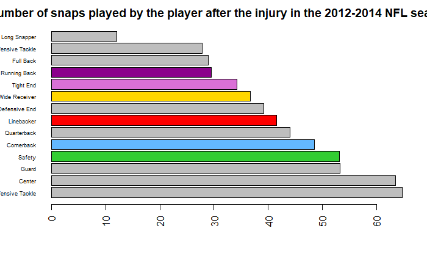

```r
snaps.positions <- snaps.positions[order(snaps.positions[,2],decreasing=TRUE),]

colnames(snaps.positions) <- c("Position", "Number of snaps")
par(las=2)
barplot(snaps.positions$`Number of snaps`,
        names = snaps.positions$Position,
        col = ifelse(snaps.positions$Position == 'Linebacker' ,'red', ifelse(snaps.positions$Position == 'Cornerback' ,'steelblue1', ifelse(snaps.positions$Position == 'Wide Receiver' ,'gold', ifelse(snaps.positions$Position == 'Safety' ,'limegreen', ifelse(snaps.positions$Position == 'Running Back' ,'darkmagenta', ifelse(snaps.positions$Position == 'Tight End' ,'orchid', 'grey')))))),
        horiz = TRUE,
        cex.names = .55,
        main="Average number of snaps played by the player after the injury in the 2012-2014 NFL seasons by posts",)
```

Mivel az erőszakos viselkedést ezzel még mindig nem tudtam magyarázni, ezért egy új dataset segítségével elkezdtem vizsgálni, hogy esetleg befolyásolja-e az agyrázkódás ‘minőségét’ (mennyire súlyos, mennyire roncsolhatja az agyat) az, hogy az egyrázkódás után a sérülést szenvedett játékos hány snapet játszott(snap: egy snap akkor kezdődik, amikor a támadó oldal egy játékosa, a center feladja a labdát maga mögé egy másik játékosnak, és akkor van vége, amikor a labda már nincs játékban (oldalvonalon kívül van, bizonyos események után földet ér stb.). Egy snap végeztével a játékosok újra felállnak támadó és védőpozícióba és indítják a következő snapet. Egy snap általában néhány másodperc.). Itt valamennyire számítottam arra, hogy a Wide Receiverek, Tight endek és Running Backek hátrébb fognak esni, mert szokás nagyobb játékok után egy-egy jól teljesítő játékost lehozni a pályáról, és általában a támadó oldalon feltűnőbb egy-egy nagyobb játék, viszont az is látszik, hogy a nem nagy sebességgel ütköző falemberek játszanak a legtöbbet a sérülés után, ami valószínűleg azért lehet, mert a falban nem olyan könnyű észrevenni egy-egy sérülést.

```r
snapsAndArrests <- merge(snaps.positions, arrests.position,  by = 'Position', all = FALSE)
snapsAndArrests
```

| Position | Number of snaps | Number of arrests |
| --- | --- | --- |
| Center | 63.57143 | 1 |
| Cornerback | 48.57627 | 21 |
| Defensive End | 39.22222 | 13 |
| Defensive Tackle | 27.76923 | 15 |
| Full Back | 29.00000 | 1 |
| Guard | 53.28000 | 5 |
| Linebacker | 41.58621 | 39 |
| Offensive Tackle | 64.77778 | 17 |
| Running Back | 29.48571 | 20 |
| Safety | 53.16279 | 16 |

[output cut: 2 more lines]

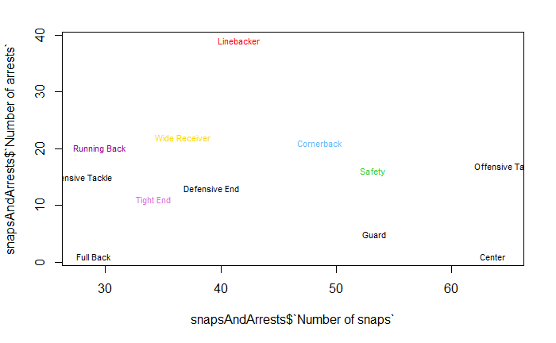

```r
plot(snapsAndArrests$`Number of snaps`, snapsAndArrests$`Number of arrests`,  type = "n")
text(snapsAndArrests$`Number of snaps`, snapsAndArrests$`Number of arrests`, labels =snapsAndArrests$Position, cex=0.7, col = ifelse(snapsAndArrests$Position == 'Linebacker' ,'red', ifelse(snapsAndArrests$Position == 'Cornerback' ,'steelblue1', ifelse(snapsAndArrests$Position == 'Wide Receiver' ,'gold', ifelse(snapsAndArrests$Position == 'Safety' ,'limegreen', ifelse(snapsAndArrests$Position == 'Running Back' ,'darkmagenta', ifelse(snapsAndArrests$Position == 'Tight End' ,'orchid', 'black')))))))
```

Viszont mivel azok, akik a legtöbbet maradtak a pályán miután fejsérülést szenvedtek általában nem követnek el annyi bűntényt, a fekete bárány még mindig a Linebacker pozíció.

Sajnos sok mindenen gondolkodtam, miért lehet ez, odáig is eljutottam, hogy az újonnan NFL-be kerülő játékosok egy általános intelligenciatesztjét vegyem figyelembe, de sajnos ezekről nem olyan sok információ érhető el, mert leginkább az irányítók szokták felhozni, ők pedig nem játszottak nagy szerepet az eddigiekben.

Arra tudok gondolni, hogy mivel az NFL játékosok nagyrésze általában próbálja a sérüléseit eltitkolni (vannak akik az agyrázkódásaikat is évekkel később vallják be), és a linebacker egy elég ‘agresszív’ poszt, ahol elég sok ütközés történik, valószínűleg az ezen a poszton játszó játékosok nem is vallják be a csapatuknak, hogy agyrázkódásuk lehet nehogy pénztől essenek el esetleges kihagyások miatt, valamint a sok kisebb ütközés sem veszélytelen, nem jár agyrázkódással vagy csak kisebb agyrázkódást szenvednek a játékosok, de az agyuk ugyanúgy károsodik tőle. Az ilyen kis ütközéseket viszont nem regisztráják sérülésként, ami elferdítheti az adatokat.